# DS 621: Homework 1 (Group3)

Homework 1 Description

Zach Alexander, Sam Bellows, Donny Lofland, Joshua Registe, Neil Shah, Aaron Zalki

## Overview

In professional sports, there is a huge interest in attempting to leverage historic statistics to both predict future outcomes (wins/losses) and explore opportunities for tuning or improving a team or individual’s performance. This data-driven approach to sports has gained a large following over the last decade and entered mass media in the form of fantasy leagues, movies (e.g. Moneyball), and websites/podcasts (e.g. FiveThirtyEight). In this analysis, we will be using a classic baseball data set with the goal to build several different models capable of predicting team wins over a season given on other team stats during that season (i.e. homeruns, strikeouts, base hits, etc).

We will first explore the data looking for issues or challenges (i.e. missing data, outliers, possible coding errors, multicollinearlity, etc). Once we have a handle on the data, we will apply any necessary cleaning steps. Once we have a reasonable dataset to work with, we will build and evaluate three different linear models that predict seasonal wins. Our dataset includes both training data and evaluation data - we will training using the main training data, then evaluate models based on how well they perform against the holdout evaluation data. Finally we will select a final model that offers the best compromise for accuracy and simplicity.

## 1. Data Exploration

*Describe the size and the variables in the moneyball training data set. Consider that too much detail will cause a manager to lose interest while too little detail will make the manager consider that you aren’t doing your job. Some suggestions are given below. Please do NOT treat this as a check list of things to do to complete the assignment. You should have your own thoughts on what to tell the boss. These are just ideas.*

### Dataset

The moneyball training set contains 17 columns–with one column our target variable “TARGET_WINS” and 2276 rows, covering baseball team performance statistics from the years 1871 to 2006 inclusive. The data has been adjusted to match the performance of a typical 162 game season. The data-set was entirely numerical and contained no categorical variables.

Below, we created a chart that describes each variable in the dataset and the theoretical effect it will have on the number of wins projected for a team.

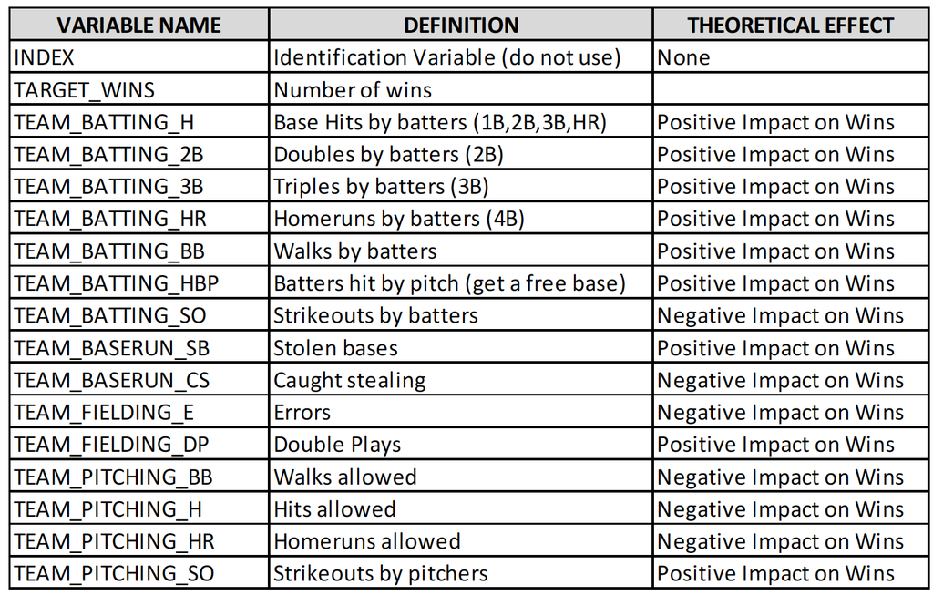

Variables of Interest

Given that the Index column had no impact on the target variable, number of wins, it was dropped.

### Summary Stats

We compiled summary statistics on our data set to better understand the data before modeling.

```
##   TARGET_WINS       BATTING_H      BATTING_2B      BATTING_3B
##  Min.   :  0.00   Min.   : 891   Min.   : 69.0   Min.   :  0.00
##  1st Qu.: 71.00   1st Qu.:1383   1st Qu.:208.0   1st Qu.: 34.00
##  Median : 82.00   Median :1454   Median :238.0   Median : 47.00
##  Mean   : 80.79   Mean   :1469   Mean   :241.2   Mean   : 55.25
##  3rd Qu.: 92.00   3rd Qu.:1537   3rd Qu.:273.0   3rd Qu.: 72.00
##  Max.   :146.00   Max.   :2554   Max.   :458.0   Max.   :223.00
##
##    BATTING_HR       BATTING_BB      BATTING_SO       BASERUN_SB
##  Min.   :  0.00   Min.   :  0.0   Min.   :   0.0   Min.   :  0.0
##  1st Qu.: 42.00   1st Qu.:451.0   1st Qu.: 548.0   1st Qu.: 66.0
##  Median :102.00   Median :512.0   Median : 750.0   Median :101.0
##  Mean   : 99.61   Mean   :501.6   Mean   : 735.6   Mean   :124.8
##  3rd Qu.:147.00   3rd Qu.:580.0   3rd Qu.: 930.0   3rd Qu.:156.0
##  Max.   :264.00   Max.   :878.0   Max.   :1399.0   Max.   :697.0
##                                   NA's   :102      NA's   :131
##    BASERUN_CS     BATTING_HBP      PITCHING_H     PITCHING_HR
##  Min.   :  0.0   Min.   :29.00   Min.   : 1137   Min.   :  0.0
##  1st Qu.: 38.0   1st Qu.:50.50   1st Qu.: 1419   1st Qu.: 50.0
##  Median : 49.0   Median :58.00   Median : 1518   Median :107.0
##  Mean   : 52.8   Mean   :59.36   Mean   : 1779   Mean   :105.7
##  3rd Qu.: 62.0   3rd Qu.:67.00   3rd Qu.: 1682   3rd Qu.:150.0
##  Max.   :201.0   Max.   :95.00   Max.   :30132   Max.   :343.0
##  NA's   :772     NA's   :2085
##   PITCHING_BB      PITCHING_SO        FIELDING_E      FIELDING_DP
##  Min.   :   0.0   Min.   :    0.0   Min.   :  65.0   Min.   : 52.0
##  1st Qu.: 476.0   1st Qu.:  615.0   1st Qu.: 127.0   1st Qu.:131.0
##  Median : 536.5   Median :  813.5   Median : 159.0   Median :149.0
##  Mean   : 553.0   Mean   :  817.7   Mean   : 246.5   Mean   :146.4
##  3rd Qu.: 611.0   3rd Qu.:  968.0   3rd Qu.: 249.2   3rd Qu.:164.0
##  Max.   :3645.0   Max.   :19278.0   Max.   :1898.0   Max.   :228.0
##                   NA's   :102                        NA's   :286
```

### Distributions

Next, we wanted to get an idea of the distribution profiles for each of the variables.

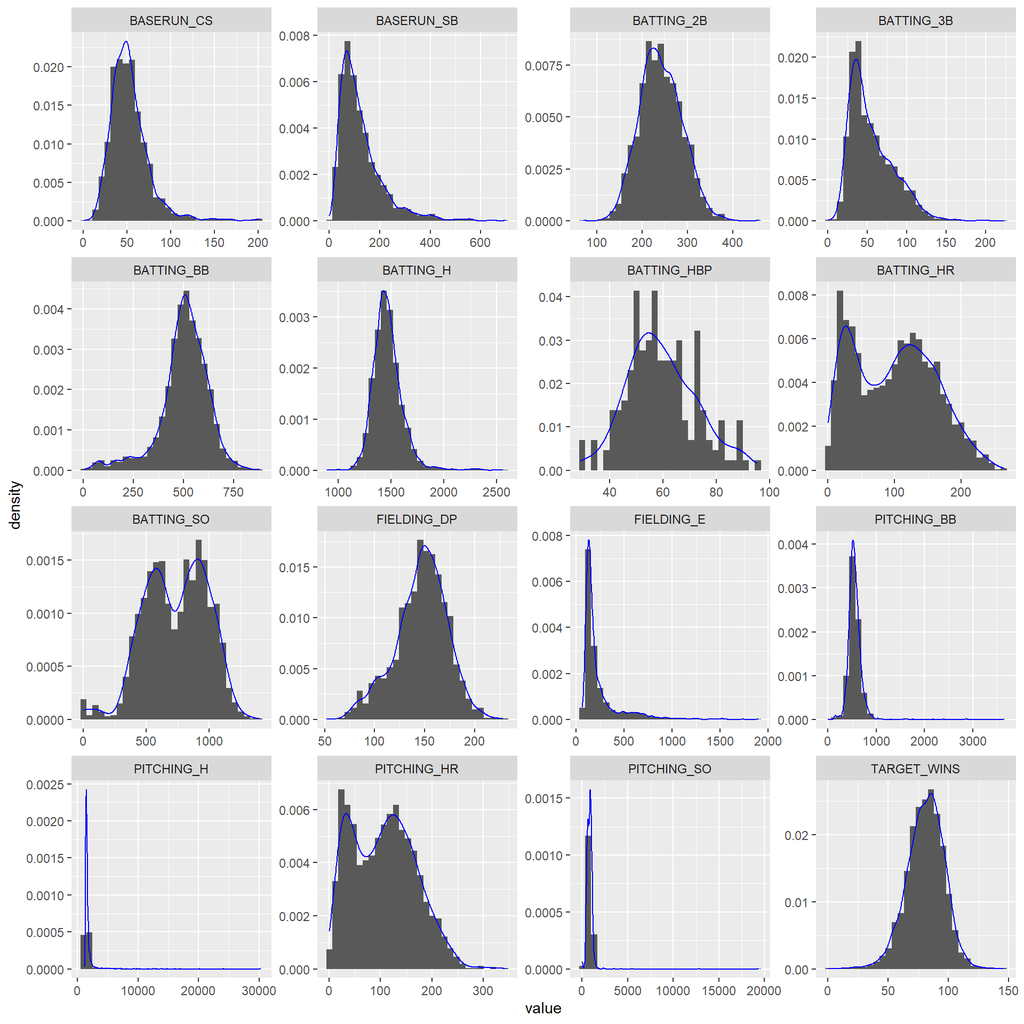

The distribution profiles sure the prevalence of kurtosis, specifically right skew in variables BASERUN_CS, BASERUN_CB, FIELDING_E, PITCHING_RB, PITCHING_H and PITCHING_SO. These deviations from a traditional normal distribution can be problematic for linear regression assumptions, and thus we might need to transform the data. Furthermore BATTING_HBP, BATTING_HR, PITCHING_HR and BATTING_SO appear bimodal. Bimodal features in a dataset are both problematic and interesting and potentially an area of opportunity and exploration. Bimodal data suggests that there are possibly two different groups or classes of baseball season data. During those seasons, teams tended to score higher or lower for the bimodal feature.

Two possibilities immediately come to mind. The bimodal nature could be caused by a rule change such that games before a specific time point had lower values and games after that point had higher values. Unfortunately, we do not have any features on which year the data is associated. The second is that teams either do well or not for the given KPI. Let’s consider BATTING_SO (Batters striking out) - if some teams have better players, they might have a reasonable normal distribution lower than those teams with worse players. We do know that certain teams are able to attract and pay for better players (let’s call them Tier 1) and some teams with lower budgets and less visibility (let’s call them Tier 2). Even with a given team, they might have “good years” and “off years”. It’s possible the distribution of BATTING_SO represents the overlap or superposition of this two distinct curves representing different classes of team.

While we don’t tackle feature engineering in this analysis, if we were performing a more in-depth analysis, these are some possible options.

- We have no data linking rows with specific years. We might attempt to locate additional data sets that link performance to year and leverage change point detection to see if bimodal relationships are linked with all teams at specific points in time. If change points are present, that suggests something changed affecting all teams (e.g. new rules that improved or lowered the bimodal feature). We would then create a new categorical feature indicating which class the row data came from, before or after the change point.
- We have no data lining rows with specific teams so cannot directly tell if there are more than one Tier of team. Instead, we could explore whether there are correlation between the bimodal nature across different bimodal features (i.e. do rows with lower BATTING_HR line up with rows with lower/higher BATTING_SO) within rows. If there are strong correlations between bimodal features, that suggests there might be two classes of teams (or yearly team performance) and we could create a new categorical variable(s) indicating the probable Tier per row. Alternatively, we could assign a new numerical feature indicating the probability a row fell into which class.
- R provides a package, `mixtools` (see R Vignette) which helps regress *mixed models* where data can be subdivided into subgroups. Here is a quick example showing a possible mix within BATTING_SO:

```
## number of iterations= 48
```

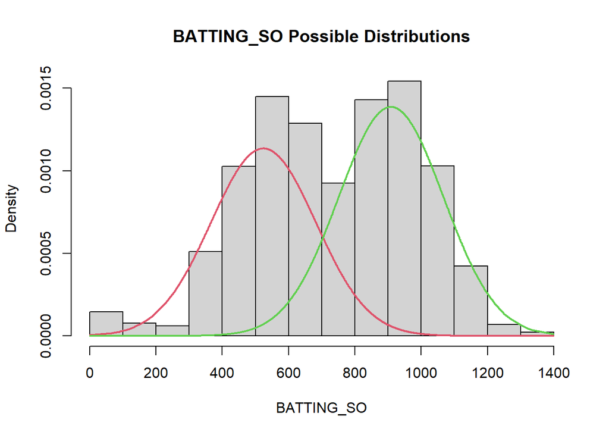

### Boxplots

In addition to creating histogram distributions, we also elected to use box-plots to get an idea of the spread of each variable.

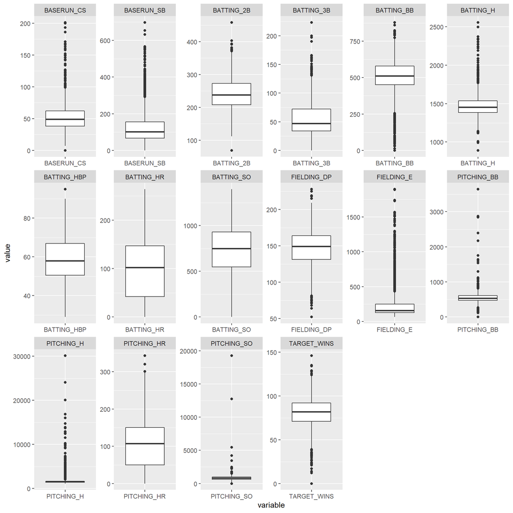

The box-plots reveal significant outliers and uniform (zero-only) values for many of our predictor variables. Outliers will need to imputed if necessary, and sparse data-sets might need to be dropped.

### Variable Plots

Finally, we wanted to plot scatter plots of each variable versus the target variable, TARGET_WINS, to get an idea of the relationship between them.

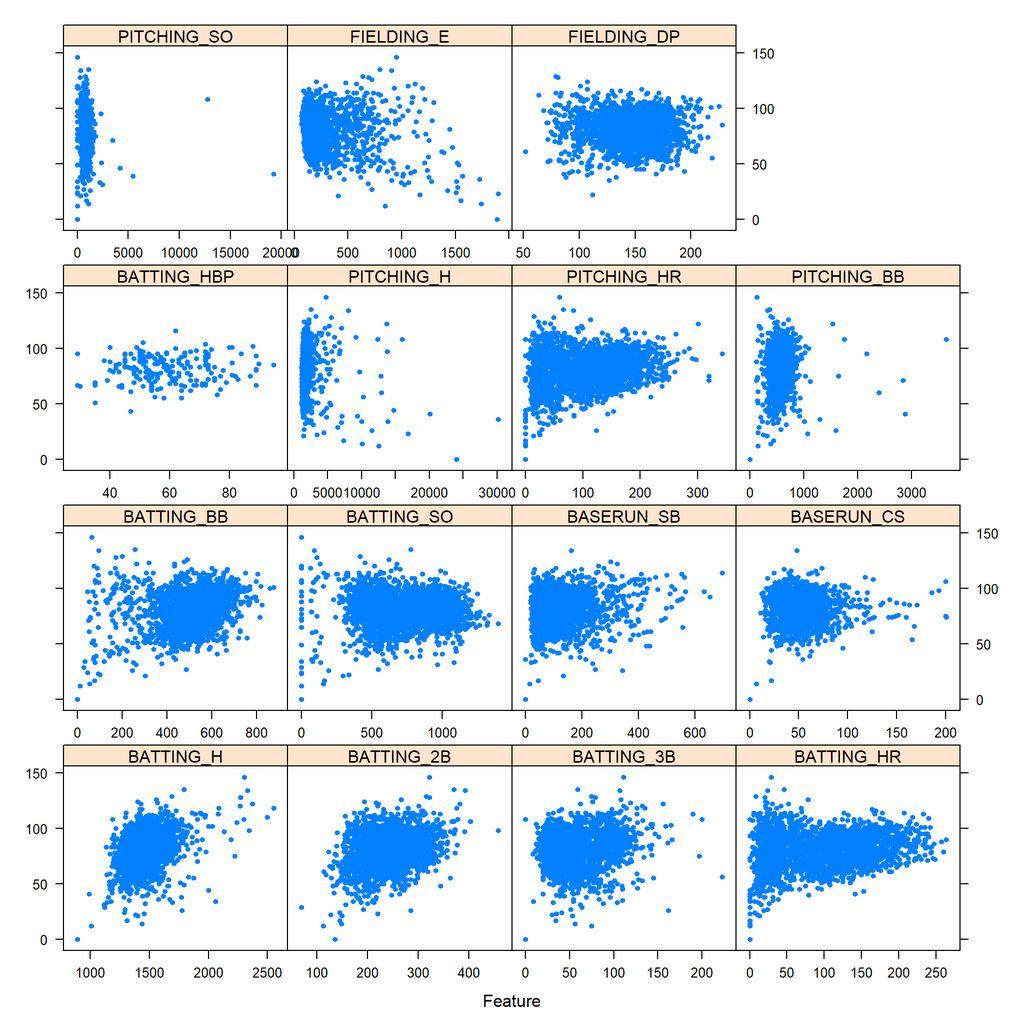

Overall, although our plots indicate some interesting relationships between our variables, they also reveal some significant issues with the data.

For instance, most of the predictor variables are skewed or non-normally distributed, and will need to be transformed. Additionally, there are many data points that contain missing data that will need to be either imputed or discarded. It also appears we have some missing data encoded as 0 and some nonsensical outliers.

There is a team with 0 wins in the dataset. This seems unlikely. Many of the hitting categories include teams at 0; it is unlikely that a team hit 0 home runs over the course of a season.

Lastly, the error variable makes little sense. From my experience watching baseball, teams usually score 2 or less errors per game, which would lead to an overall team error of approximately 320 over the course of a season, which does not match the scale of the error variable.

### Missing Data

When we initially viewed the first few rows of the raw data, we already noticed missing data. Let’s assess which fields have missing data.

```
##    values         ind
## 1   91.61 BATTING_HBP
## 2   33.92  BASERUN_CS
## 3   12.57 FIELDING_DP
## 4    5.76  BASERUN_SB
## 5    4.48  BATTING_SO
## 6    4.48 PITCHING_SO
## 7    0.00 TARGET_WINS
## 8    0.00   BATTING_H
## 9    0.00  BATTING_2B
## 10   0.00  BATTING_3B
## 11   0.00  BATTING_HR
## 12   0.00  BATTING_BB
## 13   0.00  PITCHING_H
## 14   0.00 PITCHING_HR
## 15   0.00 PITCHING_BB
## 16   0.00  FIELDING_E
```

### Feature-Target Correlations

With our missing data imputed correctly, we can now build off the scatter plots from above to quantify the correlations between our target variable and predictor variable. We will want to choose those with stronger positive or negative correlations. Features with correlations closer to zero will probably not provide any meaningful information on explaining wins by a team.

```
##          values         ind
## 1   0.383313355   BATTING_H
## 2   0.285964582  BATTING_2B
## 3   0.225471523  BATTING_BB
## 4   0.186326615 PITCHING_HR
## 5   0.173551988  BATTING_HR
## 6   0.164738136 PITCHING_BB
## 7   0.139073830  BATTING_3B
## 8   0.121110012  BASERUN_SB
## 9   0.105034615  PITCHING_H
## 10  0.009835166  BASERUN_CS
## 11 -0.030050754 FIELDING_DP
## 12 -0.037712096  BATTING_SO
## 13 -0.083637577  FIELDING_E
## 14 -0.089519609 PITCHING_SO
```

BATTING_H and BATTING_2B have the highest correlation (positive) with TOTAL_WINs; this makes sense given that more hits means more points/runs, and thus likelihood to win the game. The other variables have weak or slightly negative correlation, which can imply they might have little predictive power.

### Multicolinearity

One problem that can occur with multi-variable regression is correlation between variables, or multicolinearity. A quick check is to run correlations between variables.

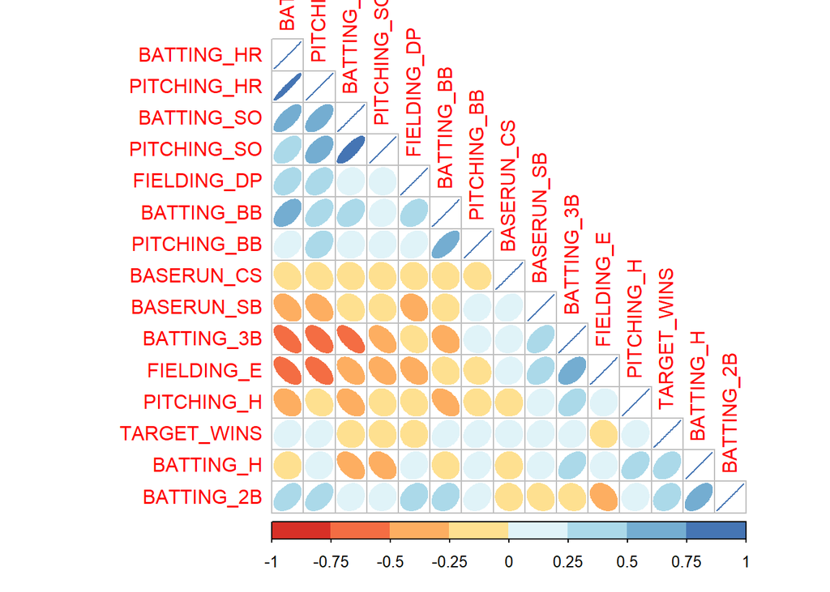

We can see that some variables are highly correlated with one another, such as PITCHING_BB and BATTING_BB. When we start considering features for our models, we’ll need to account for the correlations between features and avoid including pairs with strong correlations.

## 2. Data Preparation

To summarize our data preparation and exploration, we can distinguish our findings into a few categories below:

### Removed Fields

We removed the BATTING_HBP field as it was missing >90% of the data and the INDEX field as it offers no information for a model.

### Missing Values

There were missing values found in BASERUN_CS (Caught Stolen Bases), FIELDING_DP (Double plays), BASERUN_SB (Stolen Bases), BATTING_SO (Batter Strike outs), PITCHING_SO (Pitcher Strike outs) so we decided to replace these missing values with their corresponding median values. It is highly unlikely that teams had none of these during an entire season.

### Outliers

There are unreasonable outliers found in PITCHING_SO (pitching strikeouts), PITCHIN_H (allowed hits per game), PITCHING_BB (walks), and FIELDING_E (fielding errors) that exceed what is reasonable or possible given standard game length. While specific games might have outliers (e.g. in a game with extra innings), we wouldn’t expect the totals per season to allow for outliers in every game. Given this, we will replace any outliers with the median for the data set. Limits we set included: > 4000 PITCHING_SO (25 strikeouts per game), > 5000 PITCHING_H (30 hits allowed per game), > 2000 PITCHING_BB (13 walks per game) and > 480 FIELDING_E (3 errors per game).

### Transform non-normal variables

Finally, as mentioned earlier in our data exploration, and our findings from our histogram plots, we can see that some of our variables are highly skewed. To address this, we decided to perform some transformations to make them more normally distributed. Here are some plots to demonstrate the changes in distributions before and after the transformations:

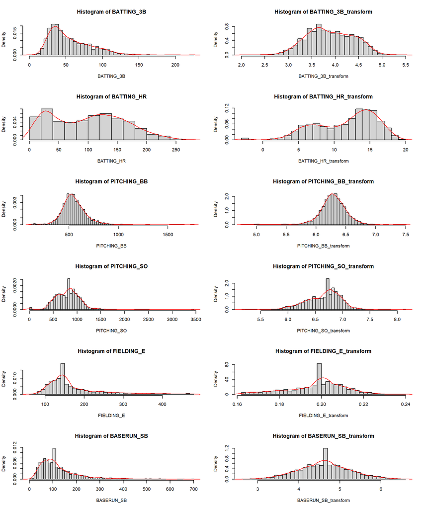

### Finalizing the dataset for model building

With our transformations complete, we can now add these into our `clean_df` dataframe and continue on to build our models.

## 3. Build Models

*Using the training data set, build at least three different multiple linear regression models, using different variables (or the same variables with different transformations). Since we have not yet covered automated variable selection methods, you should select the variables manually (unless you previously learned Forward or Stepwise selection, etc.). Since you manually selected a variable for inclusion into the model or exclusion into the model, indicate why this was done.*

*Discuss the coefficients in the models, do they make sense? For example, if a team hits a lot of Home Runs, it would be reasonably expected that such a team would win more games. However, if the coefficient is negative (suggesting that the team would lose more games), then that needs to be discussed. Are you keeping the model even though it is counter intuitive? Why? The boss needs to know.*

### Model-building methodology

With a solid understanding of our dataset at this point, and with our data cleaned, we can now start to build out some of our multiple linear regression models.

First, we decided to split our cleaned dataset into a training and testing set (80% training, 20% testing). Then, using our training dataset, we decided to run a multiple linear regression model (Model #1) that included all features that we hadn’t removed following our data cleaning process mentioned above. Next, in Model #2, to help us select the optimal set of features, we ran the `stepAIC` function in R to perform stepwise selection on our initial model to help reduce the number of features and address some of our multicollinearity issues from Model #1 (explained more below). Finally, our last model (Model #3) included all data from our cleaned dataset, but also contained some of our transformed features. We split this dataset into a training and testing set (80% training, 20% testing as well), and then substituted some of our original features with those that were transformed. Additionally, we ran this model through stepwise selection as well to determine the optimal set of features and to reduce multicollinearity as much as possible.

### Examining our model coefficients

Throughout our model-building process, we noticed that many of our outputs yielded a few coefficient values that seemed to contradict our initial estimates. For instance, in Model #1:

**Negative values for coefficients that we’d expect to be positive**

- BATTING_2B - logically more doubles hit by batters would increase the likelihood of winning more games
- BATTING_HR - logically more homeruns hit by batters would increase the likelihood of winning more games
- PITCHING_SO - logically more strikeouts thrown by pitchers would increase the likelihood of winning more games
- FIELDING_DP - logically more double plays turned by a team would increase the likelihood of winning more games

**Positive values for coefficients that we’d expect to be negative**

- BATTING_SO - logically more strikeouts by batters would lead to less of a likelihood of winning more games
- PITCHING_H - logically more hits given up by pitchers would lead to less of a likelihood of winning more games
- PITCHING_HR - logically more homeruns given up by pitchers would lead to less of a likelihood of winning more games

### Model 1

As mentioned above, below is our initial multiple linear regression model that includes all features from our cleaned dataset.

```
##
## Call:
## lm(formula = TARGET_WINS ~ BATTING_H + BATTING_2B + BATTING_3B +
##     BATTING_HR + BATTING_BB + BATTING_SO + BASERUN_SB + BASERUN_CS +
##     PITCHING_H + PITCHING_HR + PITCHING_BB + PITCHING_SO + FIELDING_E +
##     FIELDING_DP, data = df_train)
##
## Residuals:
##     Min      1Q  Median      3Q     Max
## -61.219  -8.227  -0.078   8.275  64.097
##
## Coefficients:
##              Estimate Std. Error t value Pr(>|t|)
## (Intercept) 19.159307   6.307639   3.037 0.002420 **
## BATTING_H    0.045729   0.004176  10.950  < 2e-16 ***
## BATTING_2B  -0.020206   0.010083  -2.004 0.045228 *
## BATTING_3B   0.098643   0.018671   5.283 1.42e-07 ***
## BATTING_HR  -0.064392   0.033802  -1.905 0.056944 .
## BATTING_BB   0.062187   0.005419  11.476  < 2e-16 ***
## BATTING_SO   0.006454   0.004455   1.449 0.147609
## BASERUN_SB   0.016532   0.004656   3.550 0.000394 ***
## BASERUN_CS  -0.008546   0.017416  -0.491 0.623716
## PITCHING_H   0.002280   0.001022   2.231 0.025803 *
## PITCHING_HR  0.098044   0.029903   3.279 0.001063 **
## PITCHING_BB -0.031403   0.004585  -6.848 1.02e-11 ***
## PITCHING_SO -0.006677   0.003202  -2.085 0.037196 *
## FIELDING_E  -0.046709   0.005781  -8.080 1.17e-15 ***
## FIELDING_DP -0.141952   0.014887  -9.535  < 2e-16 ***
## ---
## Signif. codes:  0 '***' 0.001 '**' 0.01 '*' 0.05 '.' 0.1 ' ' 1
##
## Residual standard error: 12.99 on 1806 degrees of freedom
## Multiple R-squared:  0.3143, Adjusted R-squared:  0.309
## F-statistic: 59.14 on 14 and 1806 DF,  p-value: < 2.2e-16
```

```
##                     2.5 %        97.5 %
## (Intercept)  6.7882721761 31.5303425736
## BATTING_H    0.0375385910  0.0539198420
## BATTING_2B  -0.0399821239 -0.0004299296
## BATTING_3B   0.0620239169  0.1352624539
## BATTING_HR  -0.1306881198  0.0019035737
## BATTING_BB   0.0515586246  0.0728152929
## BATTING_SO  -0.0022838297  0.0151917050
## BASERUN_SB   0.0073994809  0.0256640050
## BASERUN_CS  -0.0427037715  0.0256123654
## PITCHING_H   0.0002756037  0.0042835297
## PITCHING_HR  0.0393959474  0.1566927835
## PITCHING_BB -0.0403967131 -0.0224100318
## PITCHING_SO -0.0129569170 -0.0003966439
## FIELDING_E  -0.0580462638 -0.0353716216
## FIELDING_DP -0.1711508024 -0.1127541087
```

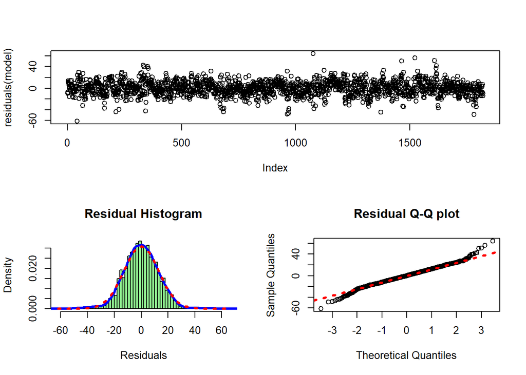

We can explicitly call out our variable importance using the Caret package which will determine our feature importance for each of the multiple linear regression models individually.

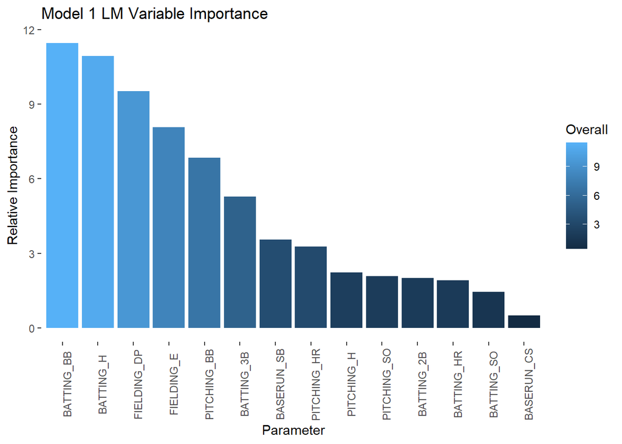

```
## [1] "VIF scores of predictors"
```

```
##   BATTING_H  BATTING_2B  BATTING_3B  BATTING_HR  BATTING_BB  BATTING_SO
##    3.982149    2.392001    2.908248   44.695422    4.722647   12.426490
##  BASERUN_SB  BASERUN_CS  PITCHING_H PITCHING_HR PITCHING_BB PITCHING_SO
##    1.700422    1.122540    2.059995   35.894247    3.740457    7.148733
##  FIELDING_E FIELDING_DP
##    1.993090    1.438791
```

### Model 2

In our second model, below, we decided to use stepwise selection in order to help us determine the optimal set of features from our original, cleaned dataset.

```
##
## Call:
## lm(formula = TARGET_WINS ~ BATTING_H + BATTING_2B + BATTING_3B +
##     BATTING_HR + BATTING_BB + BATTING_SO + BASERUN_SB + PITCHING_H +
##     PITCHING_HR + PITCHING_BB + PITCHING_SO + FIELDING_E + FIELDING_DP,
##     data = df_train)
##
## Residuals:
##     Min      1Q  Median      3Q     Max
## -61.233  -8.200  -0.015   8.302  64.234
##
## Coefficients:
##              Estimate Std. Error t value Pr(>|t|)
## (Intercept) 18.720588   6.242634   2.999 0.002747 **
## BATTING_H    0.045677   0.004174  10.943  < 2e-16 ***
## BATTING_2B  -0.020475   0.010066  -2.034 0.042098 *
## BATTING_3B   0.099109   0.018643   5.316 1.19e-07 ***
## BATTING_HR  -0.062516   0.033578  -1.862 0.062794 .
## BATTING_BB   0.062017   0.005407  11.470  < 2e-16 ***
## BATTING_SO   0.006336   0.004448   1.425 0.154462
## BASERUN_SB   0.016165   0.004595   3.518 0.000446 ***
## PITCHING_H   0.002305   0.001020   2.260 0.023947 *
## PITCHING_HR  0.097186   0.029846   3.256 0.001150 **
## PITCHING_BB -0.031213   0.004568  -6.833 1.13e-11 ***
## PITCHING_SO -0.006602   0.003198  -2.064 0.039115 *
## FIELDING_E  -0.046569   0.005772  -8.068 1.29e-15 ***
## FIELDING_DP -0.141912   0.014884  -9.534  < 2e-16 ***
## ---
## Signif. codes:  0 '***' 0.001 '**' 0.01 '*' 0.05 '.' 0.1 ' ' 1
##
## Residual standard error: 12.99 on 1807 degrees of freedom
## Multiple R-squared:  0.3143, Adjusted R-squared:  0.3093
## F-statistic:  63.7 on 13 and 1807 DF,  p-value: < 2.2e-16
```

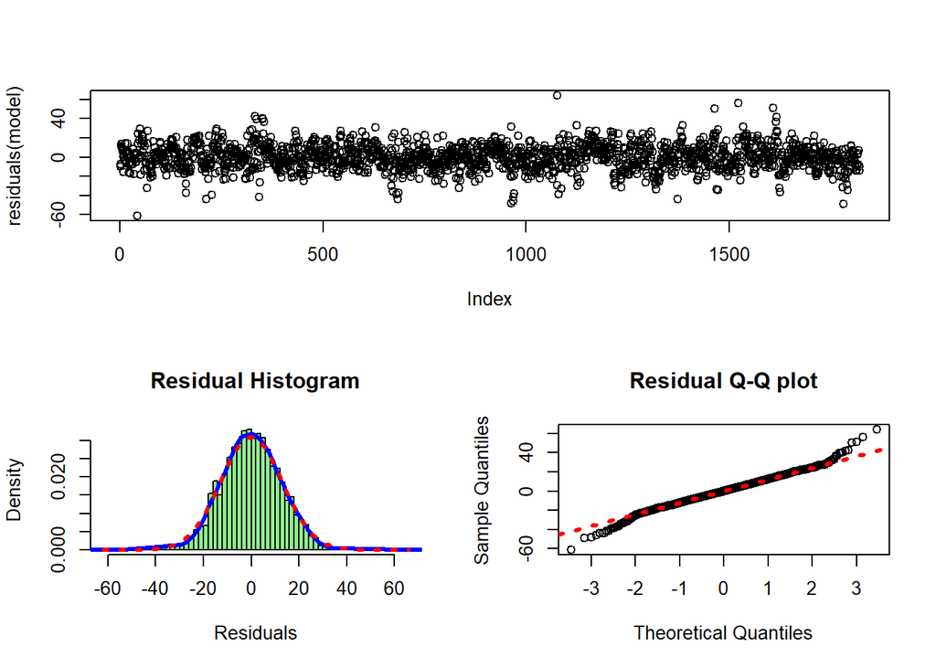

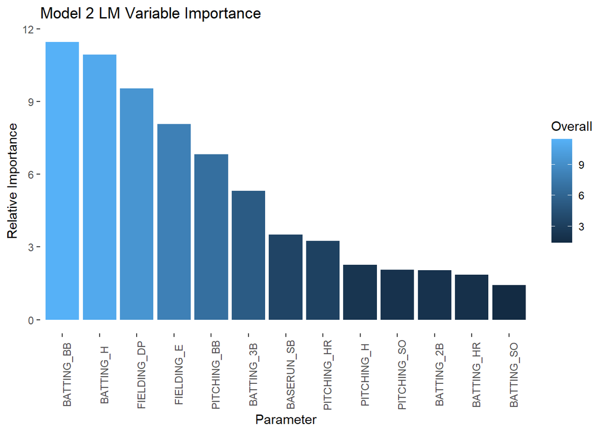

```
## [1] "VIF scores of predictors"
```

```
##   BATTING_H  BATTING_2B  BATTING_3B  BATTING_HR  BATTING_BB  BATTING_SO
##    3.979587    2.384946    2.900725   44.123572    4.703397   12.390288
##  BASERUN_SB  PITCHING_H PITCHING_HR PITCHING_BB PITCHING_SO  FIELDING_E
##    1.656576    2.054487   35.771529    3.713621    7.132372    1.988251
## FIELDING_DP
##    1.438747
```

We can also use a simple decision tree to help visualize feature importance.

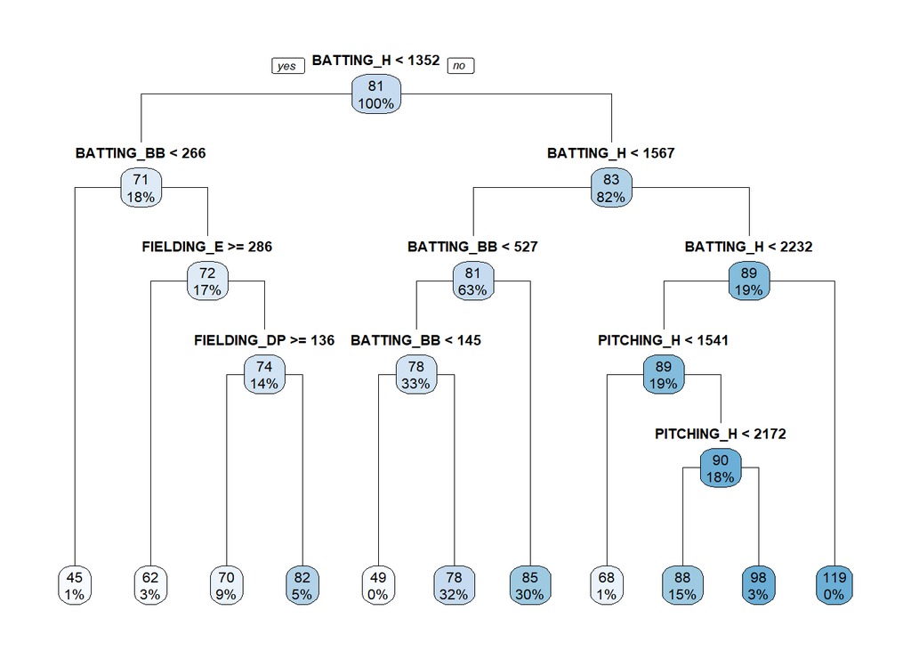

### Model 3

In our third model, we decided to utilize some of our transformed variables to compare against our initial model. Additionally, similar to model 2, we used stepwise selection to determine feature importance and select the simplest model possible.

```
##
## Call:
## lm(formula = TARGET_WINS ~ BATTING_H + BATTING_2B + BATTING_3B_transform +
##     BATTING_HR_transform + BATTING_BB + BATTING_SO + BASERUN_SB_transform +
##     BASERUN_CS + PITCHING_H + PITCHING_HR + PITCHING_BB_transform +
##     PITCHING_SO_transform + FIELDING_E_transform + FIELDING_DP,
##     data = df_train)
##
## Residuals:
##     Min      1Q  Median      3Q     Max
## -58.076  -8.145   0.051   8.272  61.294
##
## Coefficients:
##                         Estimate Std. Error t value Pr(>|t|)
## (Intercept)            8.476e+00  2.086e+01   0.406  0.68449
## BATTING_H              4.645e-02  4.162e-03  11.162  < 2e-16 ***
## BATTING_2B            -2.051e-02  1.004e-02  -2.044  0.04113 *
## BATTING_3B_transform   6.305e+00  1.013e+00   6.226 5.92e-10 ***
## BATTING_HR_transform  -5.733e-02  3.423e-01  -0.168  0.86699
## BATTING_BB             6.444e-02  6.292e-03  10.241  < 2e-16 ***
## BATTING_SO            -3.839e-03  4.378e-03  -0.877  0.38064
## BASERUN_SB_transform   2.106e+00  6.474e-01   3.252  0.00117 **
## BASERUN_CS            -7.216e-03  1.811e-02  -0.398  0.69038
## PITCHING_H             1.226e-04  1.077e-03   0.114  0.90934
## PITCHING_HR            4.067e-02  2.032e-02   2.002  0.04547 *
## PITCHING_BB_transform -1.649e+01  2.685e+00  -6.140 1.01e-09 ***
## PITCHING_SO_transform  1.557e+00  2.857e+00   0.545  0.58575
## FIELDING_E_transform   2.789e+02  3.613e+01   7.720 1.92e-14 ***
## FIELDING_DP           -1.384e-01  1.530e-02  -9.049  < 2e-16 ***
## ---
## Signif. codes:  0 '***' 0.001 '**' 0.01 '*' 0.05 '.' 0.1 ' ' 1
##
## Residual standard error: 13.04 on 1806 degrees of freedom
## Multiple R-squared:  0.309,  Adjusted R-squared:  0.3037
## F-statistic: 57.69 on 14 and 1806 DF,  p-value: < 2.2e-16
```

```
##                               2.5 %        97.5 %
## (Intercept)           -32.428934106  4.938152e+01
## BATTING_H               0.038288318  5.461267e-02
## BATTING_2B             -0.040197396 -8.267731e-04
## BATTING_3B_transform    4.319302256  8.291619e+00
## BATTING_HR_transform   -0.728612807  6.139452e-01
## BATTING_BB              0.052098342  7.678028e-02
## BATTING_SO             -0.012425392  4.747207e-03
## BASERUN_SB_transform    0.835919512  3.375463e+00
## BASERUN_CS             -0.042738724  2.830686e-02
## PITCHING_H             -0.001988975  2.234216e-03
## PITCHING_HR             0.000821262  8.052069e-02
## PITCHING_BB_transform -21.754732546 -1.122123e+01
## PITCHING_SO_transform  -4.045693300  7.160179e+00
## FIELDING_E_transform  208.032462919  3.497396e+02
## FIELDING_DP            -0.168440098 -1.084293e-01
```

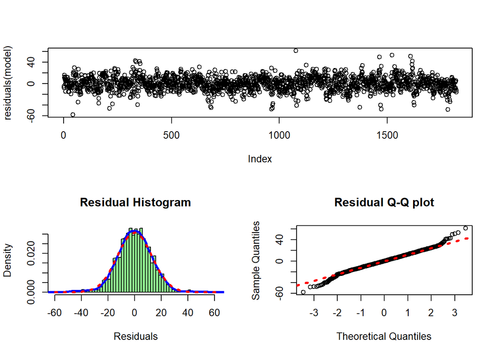

```
##
## Call:
## lm(formula = TARGET_WINS ~ BATTING_H + BATTING_2B + BATTING_3B_transform +
##     BATTING_BB + BASERUN_SB_transform + PITCHING_HR + PITCHING_BB_transform +
##     FIELDING_E_transform + FIELDING_DP, data = df_train)
##
## Residuals:
##     Min      1Q  Median      3Q     Max
## -57.878  -8.218  -0.006   8.246  60.682
##
## Coefficients:
##                         Estimate Std. Error t value Pr(>|t|)
## (Intercept)             6.879163  13.255656   0.519 0.603852
## BATTING_H               0.048322   0.003235  14.938  < 2e-16 ***
## BATTING_2B             -0.024057   0.009552  -2.518 0.011871 *
## BATTING_3B_transform    6.489195   0.995661   6.517 9.24e-11 ***
## BATTING_BB              0.060577   0.004561  13.283  < 2e-16 ***
## BASERUN_SB_transform    1.892989   0.565988   3.345 0.000841 ***
## PITCHING_HR             0.034267   0.008648   3.962 7.71e-05 ***
## PITCHING_BB_transform -15.064064   2.166169  -6.954 4.93e-12 ***
## FIELDING_E_transform  280.475431  34.237604   8.192 4.80e-16 ***
## FIELDING_DP            -0.138331   0.014738  -9.386  < 2e-16 ***
## ---
## Signif. codes:  0 '***' 0.001 '**' 0.01 '*' 0.05 '.' 0.1 ' ' 1
##
## Residual standard error: 13.03 on 1811 degrees of freedom
## Multiple R-squared:  0.3083, Adjusted R-squared:  0.3049
## F-statistic:  89.7 on 9 and 1811 DF,  p-value: < 2.2e-16
```

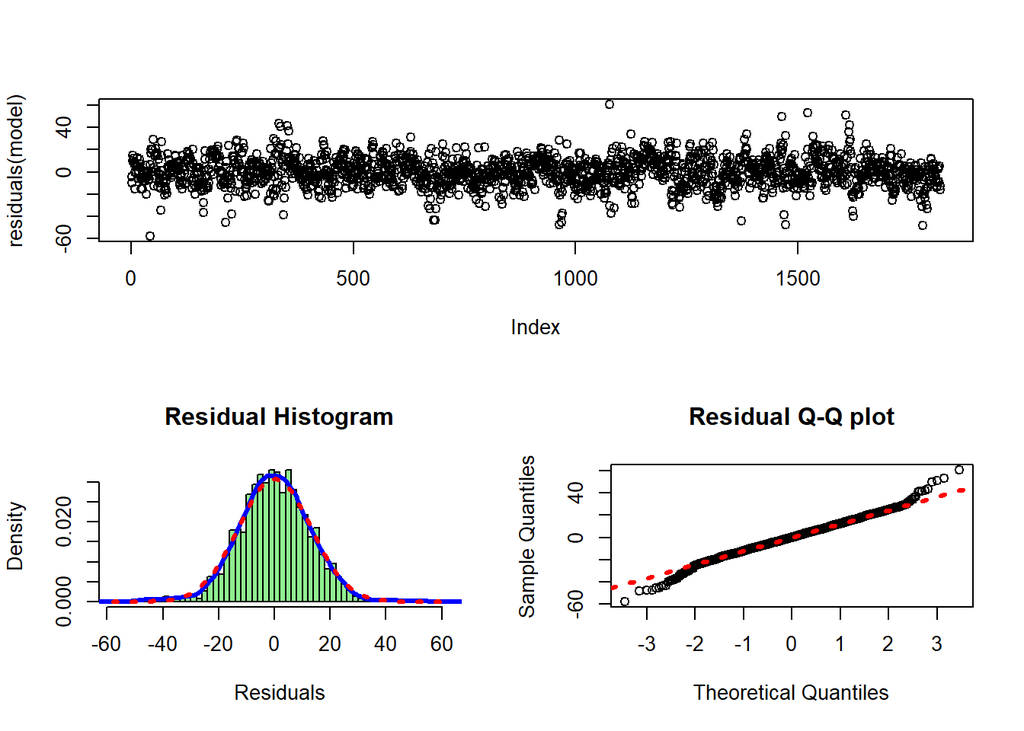

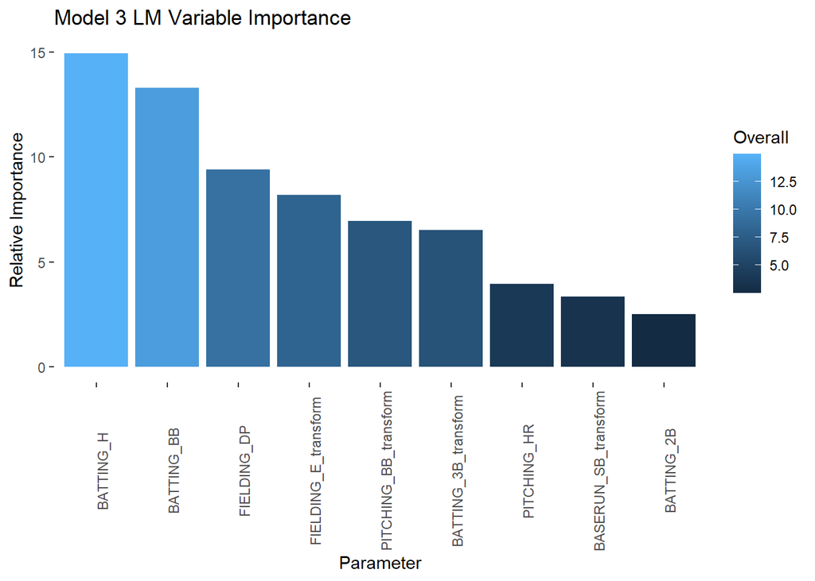

```
## [1] "VIF scores of predictors"
```

```
##             BATTING_H            BATTING_2B  BATTING_3B_transform
##              2.374987              2.133918              2.575616
##            BATTING_BB  BASERUN_SB_transform           PITCHING_HR
##              3.324985              1.333406              2.984269
## PITCHING_BB_transform  FIELDING_E_transform           FIELDING_DP
##              2.784566              2.238671              1.401629
```

## 4. Model Selection & Analysis

*For the multiple linear regression model, will you use a metric such as Adjusted R2, RMSE, etc.? Be sure to explain how you can make inferences from the model, discuss multi-collinearity issues (if any), and discuss other relevant model output. Using the training data set, evaluate the multiple linear regression model based on (a) mean squared error, (b) R2, (c) F-statistic, and (d) residual plots. Make predictions using the evaluation data set.*

All models achieved a positive adjusted R^2 pointing to a weakly-positive relationship between the target variable TOTAL_WINs and the model predictor variables.

Next looking at the F-statistic for all models were large and achieved a statistically significant p-value than than a default alpha of .05; thus for all three models the Null hypothesis that is rejected that 0s for our regression coefficients would fit the data better.

From the exploratory data analysis we saw that many of the predictor variables were correlated with each other–this makes sense given that baseball is a team sport, and thus different position scoring/runs helps contribute to wins. However this could be an issue from a multicolinearity, that can lead to unstable regression fits. From the previous section we used VIF (Variable Inflation Factor) to guage better models by preferring VIF values less than 5.

|  | RSE | Adj.R2 | F.Statistic |
| --- | --- | --- | --- |
| Model 1 | 12.99105 | 0.3090296 | 59.14120 |
| Model 2 | 12.98832 | 0.3093199 | 63.69877 |
| Model 3 | 13.02985 | 0.3048964 | 89.70165 |

The following figure represents the performance of 3 of the models on both the testing and on the training dataset. for this multiple linear regression problem, the adjusted R2 value was used as the metric for performance on predicting the target wins.

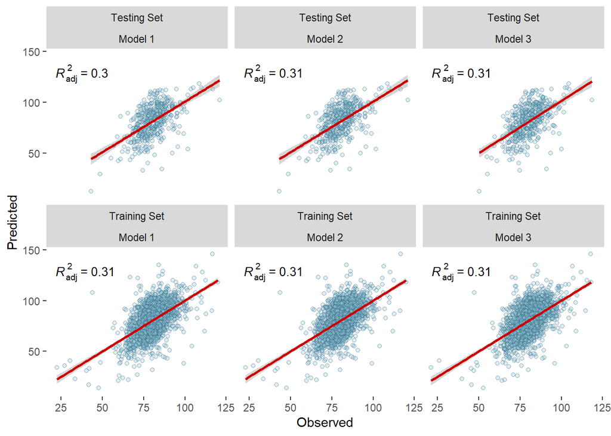

The analysis shows the following results:

Model 1 - This model is based on the all predictors on an un-transformed dataset. Results for this model provided an R^2 of about of 0.31 on the training set and 0.3 on the testing dataset.

Model 2 - This model is based on a subset of significant predictors on an un-transformed dataset. Results for this model provided an R^2 of about of 0.31 on the training set and 0.31 on the testing dataset.

Model 3 - This model is based on a subset of significant predictors on an transformed dataset. Results for this model provided an R^2 of about of 0.31 on the training set and 0.31 on the testing dataset.

## References

- A Modern Approach to Regression with R: Simon Sheather
- Linear Models with R: Julian Faraway.
- R package vignette, [mixtools: An R Package for Analyzing Finite Mixture Models](https://cran.r-project.org/web/packages/mixtools/vignettes/mixtools.pdf)
- [7 Classic OLS assumptions](https://statisticsbyjim.com/regression/ols-linear-regression-assumptions/)
- [Detecting Multicolinearity with VIF](https://online.stat.psu.edu/stat462/node/180/)

## Appendix

### A. Moneyball Dataset Columns

- INDEX: Identification Variable(Do not use)
- TARGET_WINS: Number of wins
- TEAM_BATTING_H : Base Hits by batters (1B,2B,3B,HR)
- TEAM_BATTING_2B: Doubles by batters (2B)
- TEAM_BATTING_3B: Triples by batters (3B)
- TEAM_BATTING_HR: Home runs by batters (4B)
- TEAM_BATTING_BB: Walks by batters
- TEAM_BATTING_HBP: Batters hit by pitch (get a free base)
- TEAM_BATTING_SO: Strikeouts by batters
- TEAM_BASERUN_SB: Stolen bases
- TEAM_BASERUN_CS: Caught stealing
- TEAM_FIELDING_E: Errors
- TEAM_FIELDING_DP: Double Plays
- TEAM_PITCHING_BB: Walks allowed
- TEAM_PITCHING_H: Hits allowed
- TEAM_PITCHING_HR: Homeruns allowed
- TEAM_PITCHING_SO: Strikeouts by pitchers

### R Code

```
# =====================================================================================
# Load Libraries and Define Helper functions
# =====================================================================================

library(MASS)
library(rpart.plot)
library(ggplot2)
library(ggfortify)
library(gridExtra)
library(forecast)
library(fpp2)
library(fma)
library(kableExtra)
library(e1071)
library(mlbench)
library(ggcorrplot)
library(DataExplorer)
library(timeDate)
library(caret)
library(GGally)
library(corrplot)
library(RColorBrewer)
library(tibble)
library(tidyr)
library(tidyverse)
library(dplyr)
library(reshape2)
library(mixtools)

#' Print a side-by-side Histogram and QQPlot of Residuals
#'
#' @param model A model
#' @examples
#' residPlot(myModel)
#' @return null
#' @export
residPlot <- function(model) {
  layout(matrix(c(1,1,2,3), 2, 2, byrow = TRUE))
  plot(residuals(model))
  hist(model[["residuals"]], freq = FALSE, breaks = "fd", main = "Residual Histogram",
```

[output cut: 260 more lines]

```
                         scope = list(upper = multi_lm_2, lower = ~ 1),
                         scale = 0, trace = FALSE)

# Model 2 - Show summary of revised model with only significant features included
(lmf_s_2 <- summary(mult_lm_final_2))

# model 2 - Show residual plots
residPlot(lmf_s_2)

# Model 2 - Show feature importance in final model after stepAIC
VarImpPlot(mult_lm_final_2, "Model 2 LM Variable Importance")

# =====================================================================================
# Select Models
# =====================================================================================
```